# Lecture 2: R to Stata

Dave

2024-09-13

## Two-way Interaction of Categorical Variables

### R

```r
## show model with interaction of two
## categorical variables
library(DAMisc)
## I made a 3-category income variable for the
## purposes of this exercise.  We probably
## wouldn't do this to a quantitative variable
## in 'real life'.
Duncan <- import("Duncan_cat.dta")
Duncan <- factorize(Duncan)
mod <- lm(prestige~ inc_cat * type + education,
  data=Duncan)
summary(mod)
```

```
Call:
lm(formula = prestige ~ inc_cat * type + education, data = Duncan)

Residuals:
    Min      1Q  Median      3Q     Max
-18.617  -5.999  -0.163   4.636  19.037

Coefficients:
                       Estimate Std. Error t value Pr(>|t|)
(Intercept)              7.8827     3.4364   2.294 0.027915 *
inc_catMiddle           22.4574     4.8792   4.603 5.30e-05 ***
inc_catHigh             51.2807     9.4351   5.435 4.29e-06 ***
typeprof                55.6073    11.6800   4.761 3.30e-05 ***
typewc                   2.5446     8.1162   0.314 0.755746
education                0.2799     0.1121   2.496 0.017411 *
inc_catMiddle:typeprof -41.5789    11.2428  -3.698 0.000740 ***
inc_catHigh:typeprof   -50.3567    13.3929  -3.760 0.000621 ***
inc_catMiddle:typewc   -13.0171    10.3130  -1.262 0.215223
inc_catHigh:typewc     -33.6407    13.1215  -2.564 0.014806 *
---
Signif. codes:  0 '***' 0.001 '**' 0.01 '*' 0.05 '.' 0.1 ' ' 1

Residual standard error: 9.115 on 35 degrees of freedom
Multiple R-squared:  0.9334,    Adjusted R-squared:  0.9163
F-statistic: 54.54 on 9 and 35 DF,  p-value: < 2.2e-16
```

### Stata

```stata
use Duncan_cat.dta, clear
reg prestige i.inc_cat##i.type education
```

```
      Source |       SS           df       MS      Number of obs   =        45
-------------+----------------------------------   F(9, 35)        =     54.54
       Model |   40779.914         9  4531.10155   Prob > F        =    0.0000
    Residual |  2907.73048        35  83.0780137   R-squared       =    0.9334
-------------+----------------------------------   Adj R-squared   =    0.9163
       Total |  43687.6444        44   992.90101   Root MSE        =    9.1147

------------------------------------------------------------------------------
    prestige | Coefficient  Std. err.      t    P>|t|     [95% conf. interval]
-------------+----------------------------------------------------------------
     inc_cat |
     Middle  |   22.45736   4.879245     4.60   0.000     12.55197    32.36276
       High  |   51.28067   9.435053     5.44   0.000      32.1265    70.43485
        type |
       prof  |   55.60733   11.67995     4.76   0.000     31.89576     79.3189
         wc  |   2.544598   8.116194     0.31   0.756    -13.93215    19.02135
inc_cat#type |
Middle#prof  |  -41.57887   11.24278    -3.70   0.001    -64.40292   -18.75482
  Middle#wc  |  -13.01713   10.31304    -1.26   0.215     -33.9537    7.919453
  High#prof  |  -50.35673   13.39289    -3.76   0.001    -77.54575   -23.16772
    High#wc  |  -33.64073   13.12146    -2.56   0.015    -60.27871   -7.002761
   education |   .2798811   .1121206     2.50   0.017     .0522643    .5074979
       _cons |   7.882656   3.436376     2.29   0.028     .9064417    14.85887
------------------------------------------------------------------------------
```

## Testing for significance of terms

### R

```r
## Anova (big-A) shows whether all product regressors
## are jointly significantly different from zero.
Anova(mod, type=3)
```

```
Anova Table (Type III tests)

Response: prestige
             Sum Sq Df F value    Pr(>F)
(Intercept)   437.1  1  5.2619  0.027915 *
inc_cat      3711.0  2 22.3346 5.606e-07 ***
type         2091.9  2 12.5901 7.599e-05 ***
education     517.7  1  6.2313  0.017411 *
inc_cat:type 1644.4  4  4.9484  0.002871 **
Residuals    2907.7 35
---
Signif. codes:  0 '***' 0.001 '**' 0.01 '*' 0.05 '.' 0.1 ' ' 1
```

### Stata

```stata
* Test inc_cat terms
 test (2.inc_cat = 0) (3.inc_cat = 0)

* Test type terms
test (2.type=0) (3.type=0)

* Test interaction terms
test (2.inc_cat#2.type = 0) (2.inc_cat#3.type = 0) (3.inc_cat#2.type = 0) (3.inc_cat#3.type = 0)

* Test education
test education
```

```
 ( 1)  2.inc_cat = 0
 ( 2)  3.inc_cat = 0

       F(  2,    35) =   22.33
            Prob > F =    0.0000


 ( 1)  2.type = 0
 ( 2)  3.type = 0

       F(  2,    35) =   12.59
            Prob > F =    0.0001


 ( 1)  2.inc_cat#2.type = 0
 ( 2)  2.inc_cat#3.type = 0
 ( 3)  3.inc_cat#2.type = 0
 ( 4)  3.inc_cat#3.type = 0

       F(  4,    35) =    4.95
            Prob > F =    0.0029


 ( 1)  education = 0

       F(  1,    35) =    6.23
            Prob > F =    0.0174
```

## Calculating Predicted Values for Interaction

### R

```r
## load marginal effects package
library(marginaleffects)
## generate predictions for the interaction
p1 <- predictions(mod, newdata = "mean", variables=list(inc_cat = unique, type = unique))

p1 %>%
  mutate(param = paste0("b", row_number())) %>%
  select(param, inc_cat, type, estimate, std.error, conf.low, conf.high) %>%
  as.data.frame()
```

```
  param inc_cat type estimate std.error conf.low conf.high
1    b1    High prof 79.12323  4.698512 69.91432  88.33215
2    b2    High   wc 42.77650  6.506337 30.02431  55.52869
3    b3    High   bc 73.87264  9.521451 55.21093  92.53434
4    b4  Middle prof 59.07779  4.275388 50.69818  67.45739
5    b5  Middle   wc 34.57680  6.550598 21.73786  47.41573
6    b6  Middle   bc 45.04933  4.586690 36.05958  54.03907
7    b7     Low prof 78.19929  9.772801 59.04496  97.35363
8    b8     Low   wc 25.13656  6.514249 12.36887  37.90425
9    b9     Low   bc 22.59196  4.125613 14.50591  30.67802
```

### Stata

```stata
margins inc_cat#type
```

```
Predictive margins                                          Number of obs = 45
Model VCE: OLS

Expression: Linear prediction, predict()

------------------------------------------------------------------------------
             |            Delta-method
             |     Margin   std. err.      t    P>|t|     [95% conf. interval]
-------------+----------------------------------------------------------------
inc_cat#type |
     Low#bc  |   22.59196   4.125613     5.48   0.000     14.21652     30.9674
   Low#prof  |   78.19929   9.772801     8.00   0.000     58.35945    98.03914
     Low#wc  |   25.13656   6.514248     3.86   0.000     11.91193    38.36119
  Middle#bc  |   45.04933    4.58669     9.82   0.000     35.73785     54.3608
Middle#prof  |   59.07779   4.275388    13.82   0.000     50.39829    67.75729
  Middle#wc  |    34.5768   6.550598     5.28   0.000     21.27838    47.87522
    High#bc  |   73.87264   9.521451     7.76   0.000     54.54306    93.20221
  High#prof  |   79.12323   4.698512    16.84   0.000     69.58475    88.66172
    High#wc  |    42.7765   6.506337     6.57   0.000     29.56793    55.98507
------------------------------------------------------------------------------
```

## Testing Differences in First Differences

```r
hypotheses(p1, "b3-b6 = b2 -b5",
           df = mod$df.residual)
```

```
        Term Estimate Std. Error    t Pr(>|t|)   S 2.5 % 97.5 % Df
 b3-b6=b2-b5     20.6       13.5 1.52    0.136 2.9 -6.83   48.1 35

Columns: term, estimate, std.error, statistic, p.value, s.value, conf.low, conf.high, df
Type:  response
```

```stata
margins inc_cat#type, post
test 3.inc_cat#1.type - 2.inc_cat#1.type - 3.inc_cat#3.type + 2.inc_cat#3.type = 0
```

```
Predictive margins                                          Number of obs = 45
Model VCE: OLS

Expression: Linear prediction, predict()

------------------------------------------------------------------------------
             |            Delta-method
             |     Margin   std. err.      t    P>|t|     [95% conf. interval]
-------------+----------------------------------------------------------------
inc_cat#type |
     Low#bc  |   22.59196   4.125613     5.48   0.000     14.21652     30.9674
   Low#prof  |   78.19929   9.772801     8.00   0.000     58.35945    98.03914
     Low#wc  |   25.13656   6.514248     3.86   0.000     11.91193    38.36119
  Middle#bc  |   45.04933    4.58669     9.82   0.000     35.73785     54.3608
Middle#prof  |   59.07779   4.275388    13.82   0.000     50.39829    67.75729
  Middle#wc  |    34.5768   6.550598     5.28   0.000     21.27838    47.87522
    High#bc  |   73.87264   9.521451     7.76   0.000     54.54306    93.20221
  High#prof  |   79.12323   4.698512    16.84   0.000     69.58475    88.66172
    High#wc  |    42.7765   6.506337     6.57   0.000     29.56793    55.98507
------------------------------------------------------------------------------


 ( 1)  - 2.inc_cat#1bn.type + 2.inc_cat#3.type + 3.inc_cat#1bn.type - 3.inc_cat#3.type = 0

       F(  1,    35) =    2.33
            Prob > F =    0.1363
```

## Plotting Interaction Effect

### R

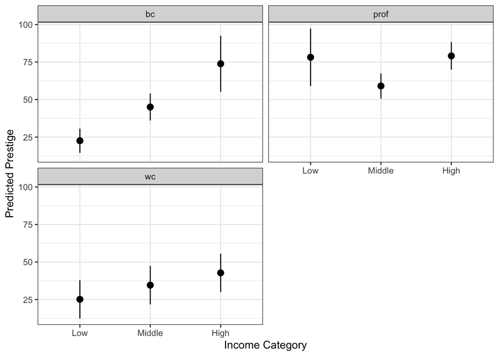

```r
## generate plot the effect with error bars
ggplot(p1) +
  geom_pointrange(aes(x=inc_cat, y=estimate,
                 ymin=conf.low,
                 ymax=conf.high)) +
  facet_wrap(~type, ncol=2) +
  theme_bw() +
  labs(x="Income Category",
       y="Predicted Prestige")
```

### Stata

```
Variables that uniquely identify margins: inc_cat type

file /Users/david/Dropbox/9592/2024/Lecture3/margins_2cat.png saved as PNG format
```

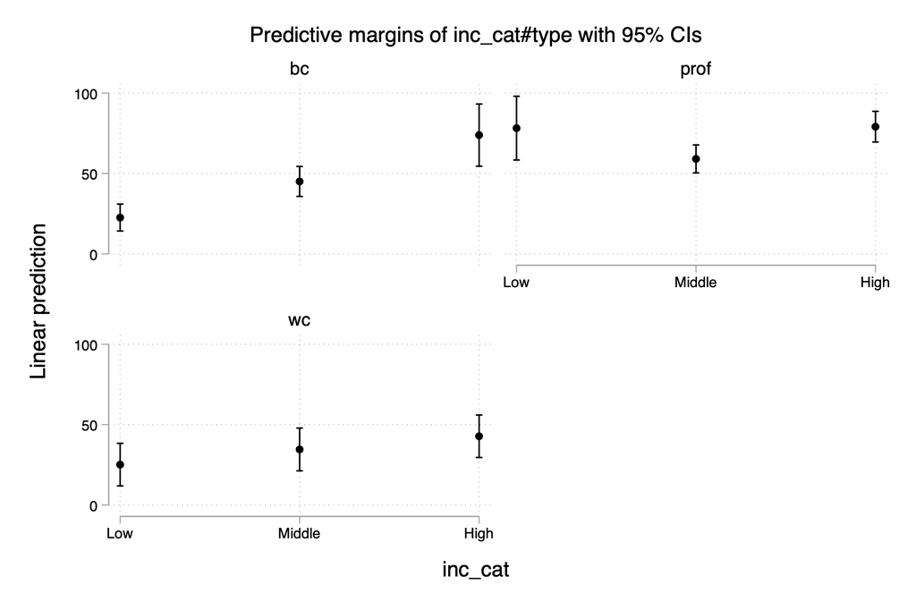

```stata
marginsplot, by(type) recast(scatter) plotopts(msymbol(circle))
graph export "margins_2cat.png", as(png) replace
```

## Interaction of Categorical by Continuous

### R

```r
data(Prestige, package="carData")
Prestige$income <- Prestige$income/1000
mod <- lm(prestige ~ income*type + education,
        data=Prestige)
summary(mod)
```

```
Call:
lm(formula = prestige ~ income * type + education, data = Prestige)

Residuals:
     Min       1Q   Median       3Q      Max
-12.8720  -4.8321   0.8534   4.1425  19.6710

Coefficients:
                Estimate Std. Error t value Pr(>|t|)
(Intercept)      -6.7273     4.9515  -1.359   0.1776
income            3.1344     0.5215   6.010 3.79e-08 ***
typeprof         25.1724     5.4670   4.604 1.34e-05 ***
typewc            7.1375     5.2898   1.349   0.1806
education         3.0397     0.6004   5.063 2.14e-06 ***
income:typeprof  -2.5102     0.5530  -4.539 1.72e-05 ***
income:typewc    -1.4856     0.8720  -1.704   0.0919 .
---
Signif. codes:  0 '***' 0.001 '**' 0.01 '*' 0.05 '.' 0.1 ' ' 1

Residual standard error: 6.455 on 91 degrees of freedom
  (4 observations deleted due to missingness)
Multiple R-squared:  0.8663,    Adjusted R-squared:  0.8574
F-statistic: 98.23 on 6 and 91 DF,  p-value: < 2.2e-16
```

## Stata

```stata
use Prestige.dta, clear
replace income = income/1000
reg prestige c.income##i.type education
```

```
variable income was long now double
(102 real changes made)

      Source |       SS           df       MS      Number of obs   =        98
-------------+----------------------------------   F(6, 91)        =     98.23
       Model |  24555.6181         6  4092.60301   Prob > F        =    0.0000
    Residual |  3791.25754        91  41.6621708   R-squared       =    0.8663
-------------+----------------------------------   Adj R-squared   =    0.8574
       Total |  28346.8756        97  292.235831   Root MSE        =    6.4546

-------------------------------------------------------------------------------
     prestige | Coefficient  Std. err.      t    P>|t|     [95% conf. interval]
--------------+----------------------------------------------------------------
       income |    3.13441   .5215479     6.01   0.000      2.09842    4.170401
         type |
        prof  |   25.17239   5.466959     4.60   0.000     14.31295    36.03183
          wc  |   7.137509   5.289818     1.35   0.181    -3.370064    17.64508
type#c.income |
        prof  |  -2.510174   .5530048    -4.54   0.000     -3.60865   -1.411698
          wc  |   -1.48556   .8720386    -1.70   0.092    -3.217757    .2466377
    education |   3.039696   .6003699     5.06   0.000     1.847135    4.232257
        _cons |  -6.727263   4.951548    -1.36   0.178    -16.56291    3.108379
-------------------------------------------------------------------------------
```

## Test coefficient groups

### R

```r
Anova(mod, type=3)
```

```
Anova Table (Type III tests)

Response: prestige
            Sum Sq Df F value    Pr(>F)
(Intercept)   76.9  1  1.8458    0.1776
income      1504.8  1 36.1180 3.788e-08 ***
type        1003.4  2 12.0427 2.291e-05 ***
education   1068.0  1 25.6344 2.142e-06 ***
income:type  890.0  2 10.6814 6.809e-05 ***
Residuals   3791.3 91
---
Signif. codes:  0 '***' 0.001 '**' 0.01 '*' 0.05 '.' 0.1 ' ' 1
```

### Stata

```stata
test 2.type 3.type
test 2.type#c.income 3.type#c.income
```

```
 ( 1)  2.type = 0
 ( 2)  3.type = 0

       F(  2,    91) =   12.04
            Prob > F =    0.0000


 ( 1)  2.type#c.income = 0
 ( 2)  3.type#c.income = 0

       F(  2,    91) =   10.68
            Prob > F =    0.0001
```

## Calculate Simple Slopes of Income

### R

```r
s <- slopes(mod, variables="income", by = "type")
s
```

```
   Term    Contrast type Estimate Std. Error    z Pr(>|z|)    S 2.5 % 97.5 %
 income mean(dY/dX) bc      3.134      0.522 6.01  < 0.001 29.0 2.112   4.16
 income mean(dY/dX) prof    0.624      0.222 2.82  0.00486  7.7 0.190   1.06
 income mean(dY/dX) wc      1.649      0.709 2.33  0.02002  5.6 0.259   3.04

Columns: term, contrast, type, estimate, std.error, statistic, p.value, s.value, conf.low, conf.high, predicted_lo, predicted_hi, predicted
Type:  response
```

```r
hypotheses(s, hypothesis = "pairwise")
```

```
      Term Estimate Std. Error     z Pr(>|z|)    S  2.5 % 97.5 %
 bc - prof     2.51      0.553  4.54   <0.001 17.4  1.426  3.594
 bc - wc       1.49      0.872  1.70   0.0885  3.5 -0.224  3.195
 prof - wc    -1.02      0.740 -1.38   0.1664  2.6 -2.476  0.426

Columns: term, estimate, std.error, statistic, p.value, s.value, conf.low, conf.high
Type:  response
```

### Stata

```stata
margins, dydx(income) at(type = (1 2 3))
margins, dydx(income) at(type = (1 2 3)) pwcompare
```

```
Average marginal effects                                    Number of obs = 98
Model VCE: OLS

Expression: Linear prediction, predict()
dy/dx wrt:  income
1._at: type = 1
2._at: type = 2
3._at: type = 3

------------------------------------------------------------------------------
             |            Delta-method
             |      dy/dx   std. err.      t    P>|t|     [95% conf. interval]
-------------+----------------------------------------------------------------
income       |
         _at |
          1  |    3.13441   .5215479     6.01   0.000      2.09842    4.170401
          2  |   .6242365   .2216518     2.82   0.006     .1839524    1.064521
          3  |   1.648851   .7089072     2.33   0.022     .2406936    3.057008
------------------------------------------------------------------------------


Pairwise comparisons of average marginal effects

Model VCE: OLS                                              Number of obs = 98

Expression: Linear prediction, predict()
dy/dx wrt:  income
1._at: type = 1
2._at: type = 2
3._at: type = 3

--------------------------------------------------------------
             |   Contrast Delta-method         Unadjusted
             |      dy/dx   std. err.     [95% conf. interval]
-------------+------------------------------------------------
income       |
         _at |
     2 vs 1  |  -2.510174   .5530048      -3.60865   -1.411698
     3 vs 1  |   -1.48556   .8720386     -3.217757    .2466377
     3 vs 2  |   1.024614   .7403864     -.4460726    2.495301
--------------------------------------------------------------
```

## Effect Plot for Income with Histogram

### R

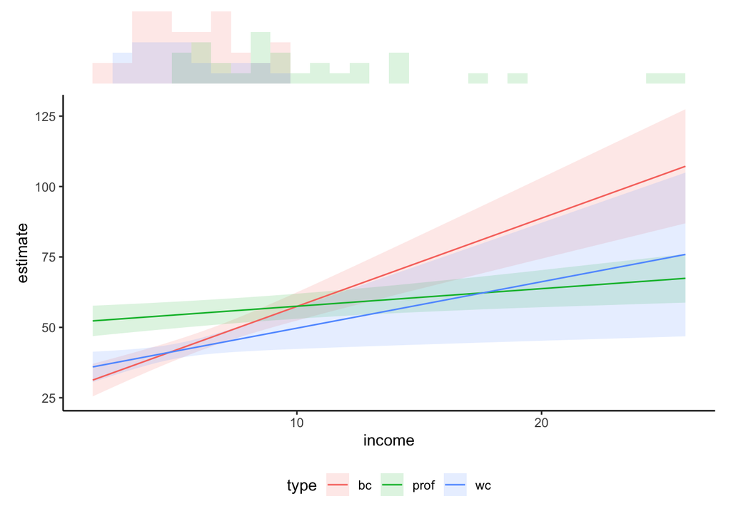

```r
preds <- predictions(mod, newdata="mean",
            variables = list(income = unique,
                             type=unique))
library(patchwork)
g1 <- ggplot(preds,
             aes(x=income,
                 y=estimate,
                 ymin=conf.low,
                 ymax=conf.high,
                 fill=type,
                 color=type)) +
  geom_ribbon(alpha=.15,
              color="transparent") +
  geom_line()  +
  theme_classic() +
  theme(legend.position="bottom")

g2 <- ggplot(Prestige %>%
               filter(!is.na(type)),
             aes(x=income,
                 fill=type)) +
  geom_histogram(position="identity",
                 alpha=.15,
                 show.legend = FALSE) +
  theme_void()

g2 +
  g1 +
  plot_layout(nrow = 2,
              heights = c(1, 4))
```

### Stata

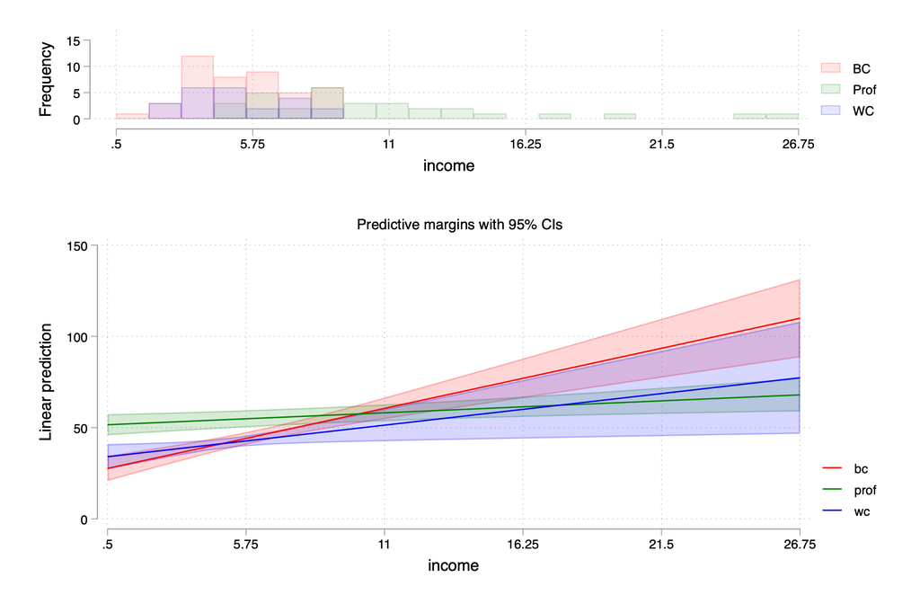

```stata
quietly margins, at(income=(.5(1.25)26.75) type=(1 2 3))
marginsplot, recast(line) recastci(rarea) ///
  ci1opts(color("red%20")) plot1opts(lcolor("red")) ///
  ci2opts(color("green%20")) plot2opts(lcolor("green") lpattern("solid")) ///
  ci3opts(color("blue%20")) plot3opts(lcolor("blue") lpattern("solid")) ///
  xlabel(.5 5.75 11 16.25 21.5 26.75) saving(m1, replace)

twoway (hist income if type == 1, color("red%20") freq width(1.25) start(.5)) ///
  (hist income if type == 2, color("green%20") freq width(1.25) start(.5)) ///
  (hist income if type == 3, color("blue%20") freq  width(1.25) start(.5)), ///
  legend(label(1 "BC") label(2 "Prof") label(3 "WC")) xlabel(.5 5.75 11 16.25 21.5 26.75) saving(h1, replace) fysize(25)
gr combine h1.gph m1.gph, cols(1)
graph export "cat_con_eff_hist.png", replace
```

## Effect of Type by Income

### R

```r
p2 <- purrr::map(c(4.6, 6.7, 8.8), \(x)
             avg_predictions(mod, newdata= datagrid(income=x), variables=list(type=unique)))

bind_rows(lapply(p2, \(x)hypotheses(x, hypothesis="pairwise")), .id="income") %>%
  as_tibble() %>%
  select(income, term, estimate, std.error, conf.low, conf.high)
```

[output not shown]

### Stata

```stata
foreach n of numlist 4.1 6.7 8.8 {
    margins type, at(income=`n') pwcompare
}
```

```
Pairwise comparisons of predictive margins                  Number of obs = 98
Model VCE: OLS

Expression: Linear prediction, predict()
At: income = 4.1

--------------------------------------------------------------
             |            Delta-method         Unadjusted
             |   Contrast   std. err.     [95% conf. interval]
-------------+------------------------------------------------
        type |
 prof vs bc  |   14.88067   4.008688      6.917908    22.84344
   wc vs bc  |   1.046714   2.605081     -4.127959    6.221387
 wc vs prof  |  -13.83396   2.850256     -19.49564   -8.172276
--------------------------------------------------------------

Pairwise comparisons of predictive margins                  Number of obs = 98
Model VCE: OLS

Expression: Linear prediction, predict()
At: income = 6.7

--------------------------------------------------------------
             |            Delta-method         Unadjusted
             |   Contrast   std. err.     [95% conf. interval]
-------------+------------------------------------------------
        type |
 prof vs bc  |   8.354222   3.554461      1.293722    15.41472
   wc vs bc  |  -2.815742    2.56755     -7.915865    2.284382
 wc vs prof  |  -11.16996   2.791322     -16.71458   -5.625345
--------------------------------------------------------------

Pairwise comparisons of predictive margins                  Number of obs = 98
Model VCE: OLS

Expression: Linear prediction, predict()
At: income = 8.8

--------------------------------------------------------------
             |            Delta-method         Unadjusted
             |   Contrast   std. err.     [95% conf. interval]
-------------+------------------------------------------------
        type |
 prof vs bc  |   3.082856   3.588572     -4.045401    10.21111
   wc vs bc  |  -5.935418   3.733788     -13.35213    1.481293
 wc vs prof  |  -9.018274   3.596303     -16.16189   -1.874659
--------------------------------------------------------------
```

## Interaction of Two Continuous Variables

### R

```r
mod <- lm(prestige ~ income*education + type, data=Prestige)
summary(mod)
```

```
Call:
lm(formula = prestige ~ income * education + type, data = Prestige)

Residuals:
     Min       1Q   Median       3Q      Max
-13.6084  -5.0225   0.3531   4.9346  17.9175

Coefficients:
                  Estimate Std. Error t value Pr(>|t|)
(Intercept)      -17.80359    7.59424  -2.344 0.021212 *
income             3.78593    0.94453   4.008 0.000124 ***
education          5.10432    0.77665   6.572 2.93e-09 ***
typeprof           5.47866    3.71385   1.475 0.143574
typewc            -3.58387    2.42775  -1.476 0.143303
income:education  -0.21019    0.06977  -3.012 0.003347 **
---
Signif. codes:  0 '***' 0.001 '**' 0.01 '*' 0.05 '.' 0.1 ' ' 1

Residual standard error: 6.806 on 92 degrees of freedom
  (4 observations deleted due to missingness)
Multiple R-squared:  0.8497,    Adjusted R-squared:  0.8415
F-statistic:   104 on 5 and 92 DF,  p-value: < 2.2e-16
```

### Stata

```stata
use Prestige.dta, clear
replace income = income/1000
reg prestige c.income##c.education i.type
```

```
variable income was long now double
(102 real changes made)

      Source |       SS           df       MS      Number of obs   =        98
-------------+----------------------------------   F(5, 92)        =    104.01
       Model |  24085.8797         5  4817.17595   Prob > F        =    0.0000
    Residual |  4260.99588        92  46.3151726   R-squared       =    0.8497
-------------+----------------------------------   Adj R-squared   =    0.8415
       Total |  28346.8756        97  292.235831   Root MSE        =    6.8055

--------------------------------------------------------------------------------------
            prestige | Coefficient  Std. err.      t    P>|t|     [95% conf. interval]
---------------------+----------------------------------------------------------------
              income |   3.785926   .9445285     4.01   0.000     1.910011    5.661841
           education |   5.104321   .7766489     6.57   0.000     3.561829    6.646813
c.income#c.education |  -.2101878    .069775    -3.01   0.003    -.3487668   -.0716087
                type |
               prof  |   5.478658   3.713849     1.48   0.144    -1.897367    12.85468
                 wc  |   -3.58387   2.427753    -1.48   0.143    -8.405596    1.237857
               _cons |  -17.80359   7.594241    -2.34   0.021    -32.88641   -2.720773
--------------------------------------------------------------------------------------
```

## Conditional Effects Plot

### R

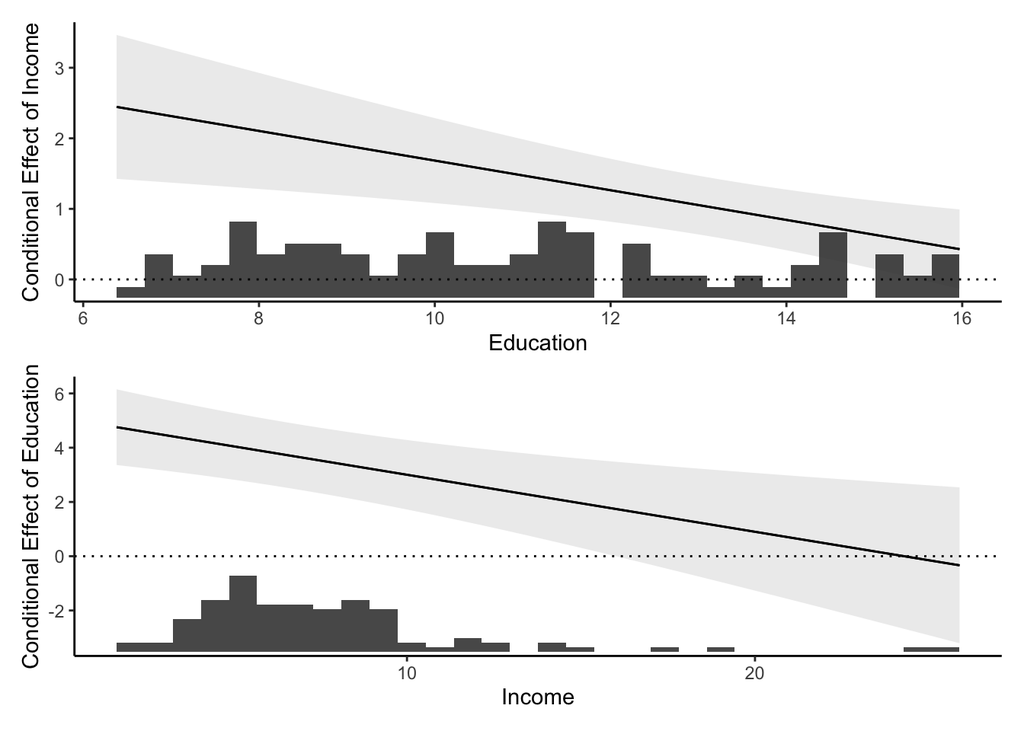

```r
library(ggplotify)
h1 <- ggplot(Prestige, aes(x=education)) +
  geom_histogram() +
  theme_void()
m1 <- plot_slopes(mod, variable="income", condition="education")  +
  geom_hline(yintercept=0, linetype=3) +
  theme_classic() +
  labs(x="Education", y="Conditional Effect of Income")
m1 <- m1 - annotation_custom(as.grob(h1), ymax=calc_ymax(m1))
m2 <- plot_slopes(mod, variable="education", condition="income") +
  geom_hline(yintercept=0, linetype=3) +
  theme_classic() +
  labs(x="Income", y="Conditional Effect of Education")
h2 <- ggplot(Prestige, aes(x=income)) +
  geom_histogram() +
  theme_void()
m2 <- m2 - annotation_custom(as.grob(h2), ymax=calc_ymax(m2))
m1 + m2 + plot_layout(nrow=2)
```

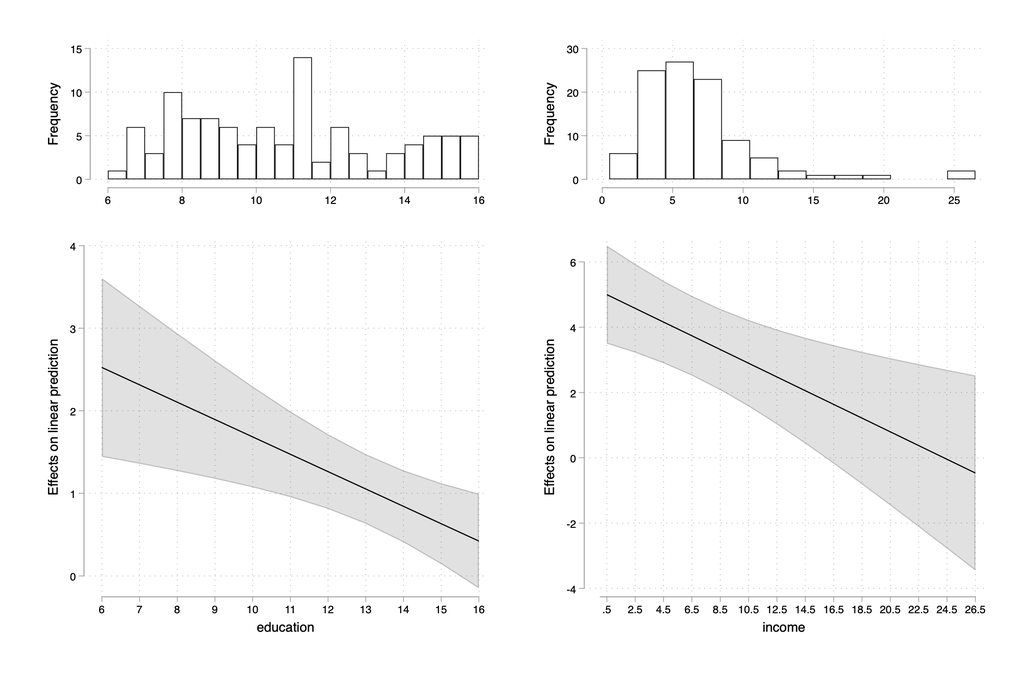

```stata
margins, dydx(income) at(education = (6(1)16))
marginsplot, recast(line) recastci(rarea) ciopts(color("%15")) saving(inc_marg, replace) title("")
twoway hist education, start(6) width(.5) saving(ed_hist, replace) freq fysize(25) xtitle("")

margins, dydx(education) at(income = (.5(2)26.5))
marginsplot, recast(line) recastci(rarea) ciopts(color("%15")) saving(ed_marg, replace) title("")
twoway hist income, start(.5) width(2) saving(inc_hist, replace) freq fysize(25) xtitle("")

gr combine ed_hist.gph inc_marg.gph, cols(1) xcommon saving(inc_eff, replace)
gr combine inc_hist.gph  ed_marg.gph, cols(1) xcommon saving(ed_eff, replace)

gr combine inc_eff.gph ed_eff.gph, cols(2)
```

## Where does significance change?

### R

```r
changeSig(mod, c("income", "education"))
```

```
LB for B(income | education) = 0 when education=15.4979 (95th pctile)
UB for B(income | education) = 0 when education=27.9396 (> Maximum Value in Data)
LB for B(education | income) = 0 when income=15.9273 (96th pctile)
UB for B(education | income) = 0 when income=59.5175 (> Maximum Value in Data)
```

### Stata

I wrote a function for Stata that would find when the significance changes. It’s in the file `changeSig.do` available on the OWL site. The required arguments are: - `xind()` the column number in the matrix of coefficients for the first constitutive effect. - `zind()` the column number in the matrix of coefficients for the second constitutive effect. - `multind()` the column number in the matrix of coefficients for the interaction coefficient.

There are also some optional arguments. - `loz` and `highz` give the range of values of `z` over which the conditional effect of `x` will be searched to find where the effect becomes (in)significant. - `lox` and `highx` give the range of values of `x` over which the conditional effect of `z` will be searched to find where the effect becomes (in)significant. - `tol` the tolerance for the root finder. - `iter` the maximum number of iterations for the root finder.

You can find the required column numbers of the coefficient by looking at the coefficient matrix:

```stata
reg prestige c.income##c.education i.type
mat list e(b)
```

```
      Source |       SS           df       MS      Number of obs   =        98
-------------+----------------------------------   F(5, 92)        =    104.01
       Model |  24085.8797         5  4817.17595   Prob > F        =    0.0000
    Residual |  4260.99588        92  46.3151726   R-squared       =    0.8497
-------------+----------------------------------   Adj R-squared   =    0.8415
       Total |  28346.8756        97  292.235831   Root MSE        =    6.8055

--------------------------------------------------------------------------------------
            prestige | Coefficient  Std. err.      t    P>|t|     [95% conf. interval]
---------------------+----------------------------------------------------------------
              income |   3.785926   .9445285     4.01   0.000     1.910011    5.661841
           education |   5.104321   .7766489     6.57   0.000     3.561829    6.646813
c.income#c.education |  -.2101878    .069775    -3.01   0.003    -.3487668   -.0716087
                type |
               prof  |   5.478658   3.713849     1.48   0.144    -1.897367    12.85468
                 wc  |   -3.58387   2.427753    -1.48   0.143    -8.405596    1.237857
               _cons |  -17.80359   7.594241    -2.34   0.021    -32.88641   -2.720773
--------------------------------------------------------------------------------------


e(b)[1,7]
                                 c.income#          1b.           2.           3.
         income    education  c.education         type         type         type        _cons
y1    3.7859259    5.1043211   -.21018776            0    5.4786585   -3.5838696   -17.803592
```

Here, we see `income` is the first one, `education` is the second one and the product regressor is the third one. We could then do the following:

```stata
do "changeSig.do"
```

```stata
changeSig, xind(1) zind(2) multind(3)
```

```
The lower bound of the conditional effect of X crosses zero when Z = : 27.94
The upper bound of the conditional effect of X crosses zero when Z = : 15.498
The lower bound of the conditional effect of Z crosses zero when X = : 59.517
The upper bound of the conditional effect of Z crosses zero when X = : 15.927
```

## Berry, Golder and Milton Hypotheses

### R

```r
library(DAMisc)
BGMtest(mod, c("income", "education"))
```

```
             est    se      t p-value
P(X|Zmin)  2.445 0.520  4.698 0.000
P(X|Zmax)  0.429 0.287  1.495 0.138
P(Z|Xmin)  4.756 0.712  6.681 0.000
P(Z|Xmax) -0.335 1.466 -0.229 0.820
P(XZ)     -0.210 0.070 -3.012 0.003
```

### Stata

In addition to looking at the interaction coefficient in the regression output, you can find the other values from the BGM test here. Note that `sum` produces a set of summary statistics that are stored in a bunch of returned local macros. `r(min)` holds the minimum value and `r(max)` the maximum. We can use those local macros rather than typing out the values.

```stata
sum educ
margins, dydx(income) at(education = (`r(min)' `r(max)'))
sum income
margins, dydx(education) at(income = (`r(min)' `r(max)'))
```

```
    Variable |        Obs        Mean    Std. dev.       Min        Max
-------------+---------------------------------------------------------
   education |        102    10.73804    2.728444       6.38      15.97


Average marginal effects                                    Number of obs = 98
Model VCE: OLS

Expression: Linear prediction, predict()
dy/dx wrt:  income
1._at: education =  6.38
2._at: education = 15.97

------------------------------------------------------------------------------
             |            Delta-method
             |      dy/dx   std. err.      t    P>|t|     [95% conf. interval]
-------------+----------------------------------------------------------------
income       |
         _at |
          1  |   2.444928    .520387     4.70   0.000     1.411394    3.478461
          2  |   .4292273   .2872044     1.49   0.138    -.1411854    .9996401
------------------------------------------------------------------------------

    Variable |        Obs        Mean    Std. dev.       Min        Max
-------------+---------------------------------------------------------
      income |        102    6.797902    4.245922       .611     25.879


Average marginal effects                                    Number of obs = 98
Model VCE: OLS

Expression: Linear prediction, predict()
dy/dx wrt:  education
1._at: income =   .611
2._at: income = 25.879

------------------------------------------------------------------------------
             |            Delta-method
             |      dy/dx   std. err.      t    P>|t|     [95% conf. interval]
-------------+----------------------------------------------------------------
education    |
         _at |
          1  |   4.975896    .751327     6.62   0.000     3.483696    6.468097
          2  |  -.3351278   1.465606    -0.23   0.820    -3.245947    2.575692
------------------------------------------------------------------------------
```

## Logit Model

### R

```r
dat <- import("data/anes2012.dta")
dat <- rio::factorize(dat)
mod <- glm(votedem ~ black + evprot + incgroup_num *lrself +
             econ_retnat, data=dat, family=binomial)
summary(mod)
```

```
Call:
glm(formula = votedem ~ black + evprot + incgroup_num * lrself +
    econ_retnat, family = binomial, data = dat)

Coefficients:
                               Estimate Std. Error z value Pr(>|z|)
(Intercept)                    3.233465   0.376286   8.593  < 2e-16 ***
black                          4.990982   0.283832  17.584  < 2e-16 ***
evprot                        -0.468994   0.156215  -3.002 0.002680 **
incgroup_num                   0.055942   0.021811   2.565 0.010320 *
lrself                        -0.216264   0.059007  -3.665 0.000247 ***
econ_retnat2. Stayed the same -1.649760   0.140876 -11.711  < 2e-16 ***
econ_retnat3. Gotten worse    -2.967728   0.154720 -19.181  < 2e-16 ***
incgroup_num:lrself           -0.018936   0.003707  -5.108 3.26e-07 ***
---
Signif. codes:  0 '***' 0.001 '**' 0.01 '*' 0.05 '.' 0.1 ' ' 1

(Dispersion parameter for binomial family taken to be 1)

    Null deviance: 4017.9  on 2918  degrees of freedom
Residual deviance: 2004.5  on 2911  degrees of freedom
AIC: 2020.5

Number of Fisher Scoring iterations: 6
```

### Stata

```stata
use data/anes2012.dta, clear
logit votedem black evprot c.incgroup_num##c.lrself i.econ_retnat
```

```
Iteration 0:  Log likelihood = -2008.9667
Iteration 1:  Log likelihood = -1044.4666
Iteration 2:  Log likelihood = -1004.8043
Iteration 3:  Log likelihood = -1002.2416
Iteration 4:  Log likelihood = -1002.2338
Iteration 5:  Log likelihood = -1002.2338

Logistic regression                                    Number of obs =   2,919
                                                       LR chi2(7)    = 2013.47
                                                       Prob > chi2   =  0.0000
Log likelihood = -1002.2338                            Pseudo R2     =  0.5011

-----------------------------------------------------------------------------------------
                votedem | Coefficient  Std. err.      z    P>|z|     [95% conf. interval]
------------------------+----------------------------------------------------------------
                  black |   4.990982   .2838634    17.58   0.000      4.43462    5.547344
                 evprot |  -.4689945   .1562173    -3.00   0.003    -.7751748   -.1628141
           incgroup_num |   .0559421   .0218109     2.56   0.010     .0131934    .0986907
                 lrself |  -.2162638   .0590084    -3.66   0.000    -.3319181   -.1006096
c.incgroup_num#c.lrself |  -.0189365   .0037074    -5.11   0.000    -.0262029     -.01167
            econ_retnat |
    2. Stayed the same  |   -1.64976   .1408772   -11.71   0.000    -1.925874   -1.373646
       3. Gotten worse  |  -2.967728   .1547217   -19.18   0.000    -3.270977   -2.664479
                  _cons |   3.233465   .3762894     8.59   0.000     2.495951    3.970978
-----------------------------------------------------------------------------------------
```

## Second Difference/Derivative

If one of the variables is continuous, you can use either a cross-derivative (a difference of two first derivatives) or a second difference (a difference of two first differences). We could first look to see how the first derivative changes as a function of the conditioning variable

### R

```r
avg_slopes(mod,
  newdata = datagrid(lrself=0:10, grid_type = "counterfactual"),
  variables="incgroup_num",
  by="lrself")
```

```
         Term    Contrast lrself  Estimate Std. Error       z Pr(>|z|)    S     2.5 %    97.5 %
 incgroup_num mean(dY/dX)      0  0.004573   0.001766  2.5890  0.00962  6.7  0.001111  0.008035
 incgroup_num mean(dY/dX)      1  0.003824   0.001849  2.0687  0.03858  4.7  0.000201  0.007447
 incgroup_num mean(dY/dX)      2  0.002215   0.001824  1.2144  0.22460  2.2 -0.001360  0.005789
 incgroup_num mean(dY/dX)      3 -0.000117   0.001619 -0.0725  0.94220  0.1 -0.003291  0.003056
 incgroup_num mean(dY/dX)      4 -0.002781   0.001304 -2.1328  0.03294  4.9 -0.005337 -0.000225
 incgroup_num mean(dY/dX)      5 -0.005389   0.001040 -5.1806  < 0.001 22.1 -0.007428 -0.003350
 incgroup_num mean(dY/dX)      6 -0.007654   0.000963 -7.9444  < 0.001 48.9 -0.009542 -0.005766
 incgroup_num mean(dY/dX)      7 -0.009295   0.001035 -8.9771  < 0.001 61.6 -0.011324 -0.007266
 incgroup_num mean(dY/dX)      8 -0.010099   0.001135 -8.8967  < 0.001 60.6 -0.012324 -0.007874
 incgroup_num mean(dY/dX)      9 -0.010190   0.001245 -8.1864  < 0.001 51.7 -0.012630 -0.007750
 incgroup_num mean(dY/dX)     10 -0.009960   0.001371 -7.2651  < 0.001 41.3 -0.012647 -0.007273

Columns: term, contrast, lrself, estimate, std.error, statistic, p.value, s.value, conf.low, conf.high, predicted_lo, predicted_hi, predicted
Type:  response
```

### Stata

```stata
margins, dydx(incgroup_num) at(lrself = (0(1)10))
```

```
Average marginal effects                                 Number of obs = 2,919
Model VCE: OIM

Expression: Pr(votedem), predict()
dy/dx wrt:  incgroup_num
1._at:  lrself =  0
2._at:  lrself =  1
3._at:  lrself =  2
4._at:  lrself =  3
5._at:  lrself =  4
6._at:  lrself =  5
7._at:  lrself =  6
8._at:  lrself =  7
9._at:  lrself =  8
10._at: lrself =  9
11._at: lrself = 10

------------------------------------------------------------------------------
             |            Delta-method
             |      dy/dx   std. err.      z    P>|z|     [95% conf. interval]
-------------+----------------------------------------------------------------
incgroup_num |
         _at |
          1  |   .0045728   .0017661     2.59   0.010     .0011112    .0080344
          2  |   .0038241   .0018486     2.07   0.039      .000201    .0074472
          3  |   .0022148   .0018238     1.21   0.225    -.0013597    .0057893
          4  |  -.0001174   .0016191    -0.07   0.942    -.0032907    .0030559
          5  |  -.0027813    .001304    -2.13   0.033    -.0053371   -.0002254
          6  |  -.0053888   .0010402    -5.18   0.000    -.0074276     -.00335
          7  |   -.007654   .0009635    -7.94   0.000    -.0095424   -.0057657
          8  |  -.0092949   .0010354    -8.98   0.000    -.0113243   -.0072656
          9  |  -.0100993   .0011352    -8.90   0.000    -.0123243   -.0078742
         10  |    -.01019   .0012448    -8.19   0.000    -.0126297   -.0077503
         11  |    -.00996    .001371    -7.26   0.000    -.0126471    -.007273
------------------------------------------------------------------------------
```

We see that the biggest positive effect of `incgroup_num` is when `lrself` is 0 and the biggest negative effect is when `lrself` is 9. We could test the difference of those two effects.

### R

```r
avg_slopes(mod,
  newdata = datagrid(lrself=c(0,9), grid_type = "counterfactual"),
  variables="incgroup_num",
  by="lrself",
  hypothesis = "b2-b1=0")
```

```
    Term Estimate Std. Error     z Pr(>|z|)    S   2.5 %   97.5 %
 b2-b1=0  -0.0148    0.00271 -5.45   <0.001 24.3 -0.0201 -0.00946

Columns: term, estimate, std.error, statistic, p.value, s.value, conf.low, conf.high
Type:  response
```

### Stata

```stata
margins, dydx(incgroup_num) at(lrself= (0 9)) pwcompare
```

```
Pairwise comparisons of average marginal effects

Model VCE: OIM                                           Number of obs = 2,919

Expression: Pr(votedem), predict()
dy/dx wrt:  incgroup_num
1._at: lrself = 0
2._at: lrself = 9

--------------------------------------------------------------
             |   Contrast Delta-method         Unadjusted
             |      dy/dx   std. err.     [95% conf. interval]
-------------+------------------------------------------------
incgroup_num |
         _at |
     2 vs 1  |  -.0147628   .0027069     -.0200682   -.0094575
--------------------------------------------------------------
```

We could also do the same with first differences:

### R

```r
avg_comparisons(mod,
  newdata = datagrid(lrself=c(0,9), grid_type = "counterfactual"),
  variables="incgroup_num",
  by="lrself",
  hypothesis = "b2-b1=0")
```

```
    Term Estimate Std. Error     z Pr(>|z|)    S   2.5 %   97.5 %
 b2-b1=0  -0.0145    0.00263 -5.51   <0.001 24.8 -0.0197 -0.00935

Columns: term, estimate, std.error, statistic, p.value, s.value, conf.low, conf.high
Type:  response
```

### Stata

```stata
margins, at(lrself=(0 9)) at(lrself=(0 9) incgroup_num=generate(incgroup_num+1)) post
lincom (4._at - 3._at) - (2._at - 1._at)
```

```
Predictive margins                                       Number of obs = 2,919
Model VCE: OIM

Expression: Pr(votedem), predict()
1._at: lrself       =              0
2._at: lrself       =              9
3._at: incgroup_num = incgroup_num+1
       lrself       =              0
4._at: incgroup_num = incgroup_num+1
       lrself       =              9

------------------------------------------------------------------------------
             |            Delta-method
             |     Margin   std. err.      z    P>|z|     [95% conf. interval]
-------------+----------------------------------------------------------------
         _at |
          1  |   .8883225   .0158535    56.03   0.000     .8572502    .9193948
          2  |   .3399001   .0111699    30.43   0.000     .3180074    .3617928
          3  |     .89283   .0153715    58.08   0.000     .8627023    .9229576
          4  |   .3299024   .0108384    30.44   0.000     .3086596    .3511453
------------------------------------------------------------------------------


 ( 1)  1bn._at - 2._at - 3._at + 4._at = 0

------------------------------------------------------------------------------
             | Coefficient  Std. err.      z    P>|z|     [95% conf. interval]
-------------+----------------------------------------------------------------
         (1) |  -.0145051   .0026307    -5.51   0.000    -.0196612   -.0093491
------------------------------------------------------------------------------
```

## Effect plot for Interaction

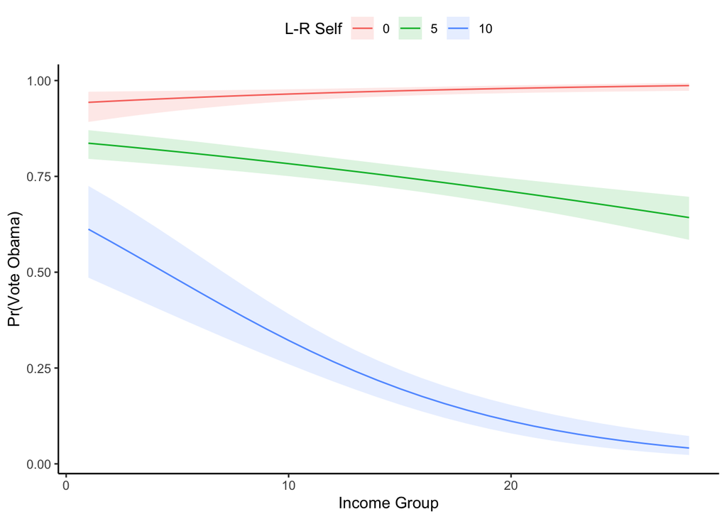

```r
pv <- avg_predictions(mod,
        newdata = datagrid(lrself=c(0,5,10), grid_type="counterfactual"),
        variables=list(incgroup_num=unique),
        by=c("lrself", "incgroup_num")) %>%
  mutate(cond = as.factor(lrself))

ggplot(pv, aes(x=incgroup_num,
               y=estimate,
               ymin=conf.low,
               ymax=conf.high,
               fill=cond)) +
  geom_ribbon(alpha=.15, color="transparent") +
  geom_line(aes(color=cond)) +
  theme_classic() +
  theme(legend.position="top") +
  labs(x="Income Group",
       y="Pr(Vote Obama)",
       colour="L-R Self", fill="L-R Self")
```

```stata
quietly logit votedem black evprot c.incgroup_num##c.lrself i.econ_retnat
quietly margins, at(incgroup_num = (1(1)28) lrself = (0 5 10))
marginsplot, recast(line) recastci(rarea) ///
  plot1opts(lcolor("red")) ///
  plot2opts(lcolor("green")) ///
  plot3opts(lcolor("blue") lpattern("solid")) ///
  ci1opts(color("red%15")) ///
  ci2opts(color("green%15")) ///
  ci3opts(color("blue%15")) ///
  xtitle("Income Group") ///
  ytitle("Predicted Pr(Vote Obama)")
```

[figure not shown]

```r
knitr::include_graphics("inc_ed_eff_stata.png")
```